# Noisy Scaling Laws (In Progress!)

Now we are set to explore the effect of noise on learning with reservoir computers. We consider a very simple noise model - we add independent Gaussian noise to each entry of the data matrix. This is effectively a form of observation error. We scan over different values of noise and reservoir size. These kinds of arguments are generally called scaling laws.

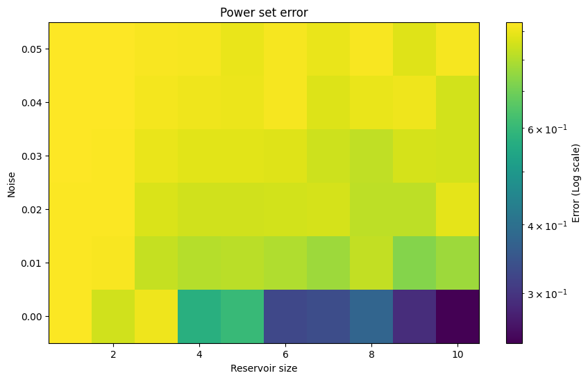

```python
import matplotlib.pyplot as plt
import matplotlib.colors as colors
from reservoir import get_data
import numpy as np
import pickle as pkl

noise_values = [0.05, 0.04, 0.03, 0.02, 0.01, 0] # standard deviations for Gaussian observation noise.

keys, Z, norm = get_data(noise_values)
X = np.array(keys)  # Reservoir sizes
Y = np.array(noise_values)  # Noise values

plt.pcolormesh(X, Y, Z, norm=norm, shading='auto', cmap='viridis')
plt.title('Power set error')
plt.xlabel('Reservoir size')
plt.ylabel('Noise')
plt.colorbar(label='Error (Log scale)')
plt.show()
```

The power set collection does better, at larger reservoir sizes, and less noise. We see that the reservoir performance rapidly improves with reservoir size and small noise, and sharply declines with noise. But how sharply? Let's look at the horizontal slices, to see the functional scaling with reservoir size.

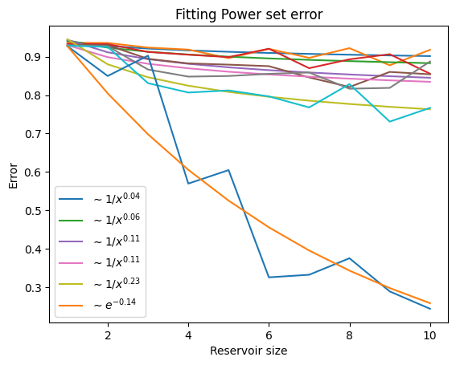

```python
from scipy.optimize import curve_fit
import numpy as np

# Define your function here
def inverse_poly(x, a, b, c):
    return a / (x ** b) + .5

def exponential(x, a, b):
    return a*np.exp(-b * x)/np.exp(-b)

# For each signal in Z, estimate the parameters
inverse_poly_parms = []
for i in range(len(Z)-1):
    # Use the bounds keyword argument to set c >= 0
    p_opt, _ = curve_fit(inverse_poly, X, Z[i], maxfev=10000, bounds=([0, 0, 0], [1, 1, 1]))
    inverse_poly_parms.append(p_opt)

# For the last signal in Z, estimate the parameters for the exponential
exp_parms, _ = curve_fit(lambda x, b: exponential(x, Z[-1][0], b), X, Z[-1])

# Now plot the functions using the estimated parameters
for i, parms in enumerate(inverse_poly_parms):
    plt.plot(X, inverse_poly(X, *parms), label=f'$\sim 1/x^{{{round(parms[1], 2)}}}$')
    plt.plot(X, Z[i])
plt.plot(X, Z[-1])
plt.plot(X, exponential(X, Z[-1][0], *exp_parms), label=f'$\sim e^{{-{np.round(exp_parms[0],2)}}}$')
plt.title('Fitting Power set error')
plt.xlabel('Reservoir size')
plt.ylabel('Error')
plt.legend()
plt.show()
```

What we are interested in is not the quantitative values, but rather the qualitative change in the functional form of the reservoir performance. We expect there the be an exponential reduction, so that the scaling law is polynomial, that is error $\sim a/n^b + c$. As noise goes to zero, $b\rightarrow \infty$, and $c\rightarrow 0$. For large enough noise, $c \rightarrow .5$, since the best the reservoir can do is randomly guess. And so we see an example of the exponential decrease in computational utility of a reservoir computer in the presence of noise. While the noiseless reservoir (orange/blue) exponentially increases performance with system size, the remaining reservoirs with noise decrease only inverse polynomially.